# Caso grupal 2: Implementación y agregación de segmentadores

Autores: Mikel Aldalur Corta, Elena Murga Martínez y David Caviedes Velasco.(equipo 18, grupo 1)

En esta actividad consta de la implementación de cuatro segmentadores. Se ha elegido la segmentación aplicada a personas y más específicamente a futbolistas en campos de fútbol. Se considera que esta técnica podría resultar útil de cara a automatizar la identificación de futbolistas en el campo durante un partido, además de la posición del balón, y por tanto facilitaría la revisión de jugadas. Los segmentadores que se han utilizado han sido:

- El Segmentador Felzenswalb **[1]**
- El Segmentador Slic **[2]**
- El Segmentador Quickshift **[3]**
- El Segmentador Watershed **[4]**

Se utiliza el cáculo de pesos entre los resultados de los segmentadores para obtener un mejor resultado mediante RAG.

- El Region Adjacency Graph **[5]**

Después se usan las diferentes funciones para la comparación y valoración de los segmentadores:

- Comparacion de segmentadores **[6]**
- Valoracion de segmentadores **[7]**

En cuanto a las métricas, como la superficie de la foto con los objetos a detectar es muy inferior a la superficie de fondo se utilizan la matriz de confusión, Intersection over Union y el informe de la clasificación, especialmente para ver el F1-score.

Tras implementar los cuatro segmentadores se utiliza un sistema de votación para combinarlos. Básicamente el sistema toma la foto pixel a pixel y hace una media ponderada de las salidas de los cuatro segmentadores. Si la media supera un cierto umbral se toma el pixel como parte del objeto a identificar. Tanto el valor de los pesos de cada segmentador como el valor umbral se han obtenido de forma experimental, en base a la experiencia con un conjunto de imágenes. En concreto, los pesos se obtienen en base al valor de F1-score de las fotos, para que los segmentadores más fiables tengan mayor influencia en la decisión.

#### Referencias

**[1]** https://scikit-image.org/docs/dev/api/skimage.segmentation.html#skimage.segmentation.felzenszwalb

**[2]** https://scikit-image.org/docs/0.14.x/api/skimage.segmentation.html#skimage.segmentation.slic

**[3]** https://scikit-image.org/docs/dev/api/skimage.segmentation.html#skimage.segmentation.quickshift

**[4]** https://scikit-image.org/docs/0.14.x/api/skimage.segmentation.html#skimage.segmentation.watershed

**[5]** https://scikit-image.org/docs/dev/auto_examples/segmentation/plot_rag.html

**[6]** https://scikit-image.org/docs/stable/auto_examples/segmentation/plot_segmentations.html

**[7]** https://towardsdatascience.com/how-accurate-is-image-segmentation-dd448f896388

```python
import matplotlib.pyplot as plt
import numpy as np
import seaborn as sn

from skimage.color import rgb2gray
from skimage.future import graph
from skimage.filters import sobel, gaussian
from skimage.segmentation import felzenszwalb, slic, quickshift,watershed
from skimage.segmentation import mark_boundaries
from skimage.util import img_as_float
from skimage import io

from sklearn.metrics import confusion_matrix, classification_report, jaccard_score, f1_score
```

```python
def norm_binary_image(imagen):
    '''
    Esta función realiza la binarización de la imagen de la mascara que estara en blanco y negro (0 y 255), que lo pasa a 0 y 1.

    Parámetros
    ----------
    imagen: np.array (imagen en escala de grises)

    Returns
    -------
    img_norm: np.array (imagen normalizada en 0 y 1)
    '''
    img_norm = np.zeros([imagen.shape[0], imagen.shape[1]],dtype=np.uint8)
    for i in range(imagen.shape[0]):
        for j in range(imagen.shape[1]):
            if imagen[i][j] == 255:
                img_norm[i][j] = 1
    return img_norm
```

```python
def binaryze_image(imagen):
    '''
    Esta función realiza la binarización de la imagen del segmentador utilizado, devuelve una imagen de 0 y 1.

    Parámetros
    ----------
    imagen: np.array (imagen en escala de grises)

    Returns
    -------
    img_aux: np.array (imagen normalizada en 0 y 1)
    '''
    img_aux = np.zeros([imagen.shape[0],imagen.shape[1]],dtype=np.uint8)
    for i in range(imagen.shape[0]):
        for j in range(imagen.shape[1]):
            if imagen[i][j] != 0:
                img_aux[i][j] = 1
    plt.imshow(img_aux)
    plt.show()
    return img_aux
```

```python
def apply_felzenswalb(img):
    '''
    Esta función aplica el segmentador Felzenswalb y después se le aplica la función rag para bajar número de labels.

    Parámetros
    ----------
    img: np.array (imagen en RGB)

    Returns
    -------
    imagen binarizada: np.array (imagen en labels 0 (fondo) y 1 (elementos detectados))
    '''
    print('Segmentador felzenswalb:')
    segments_fz = felzenszwalb(img, scale=100, sigma=0.1, min_size=100)
    plt.imshow(mark_boundaries(img, segments_fz))
    plt.show()
    rag = graph.rag_mean_color(img, segments_fz)
    segments_fz_new = graph.cut_threshold(segments_fz, rag, 35)
    plt.imshow(mark_boundaries(img, segments_fz_new))
    plt.show()
    return binaryze_image(segments_fz_new)
```

```python
def apply_slic(img):
    '''
    Esta función aplica el segmentador slic y después se le aplica la función rag para bajar número de labels.

    Parámetros
    ----------
    img: np.array (imagen en RGB)

    Returns
    -------
    imagen binarizada: np.array (imagen en labels 0 (fondo) y 1 (elementos detectados))
    '''
    print('Segmentador slic:')
    segments_slic = slic(img, n_segments=250, compactness=15, sigma=1, start_label=1)
    plt.imshow(mark_boundaries(img, segments_slic))
    plt.show()
    rag = graph.rag_mean_color(img, segments_slic)
    segments_slic_new = graph.cut_threshold(segments_slic, rag, 35)
    plt.imshow(mark_boundaries(img, segments_slic_new))
    plt.show()
    return binaryze_image(segments_slic_new)
```

```python
def apply_quick(img):
    '''
    Esta función aplica el segmentador quick y después se le aplica la función rag para bajar número de labels.

    Parámetros
    ----------
    img: np.array (imagen en RGB)

    Returns
    -------
    imagen binarizada: np.array (imagen en labels 0 (fondo) y 1 (elementos detectados))
    '''
    print('Segmentador quickshift:')
    segments_quick = quickshift(img, kernel_size=3, max_dist=6, ratio=0.5)
    plt.imshow(mark_boundaries(img, segments_quick))
    plt.show()
    rag = graph.rag_mean_color(img, segments_quick)
    segments_quick_new = graph.cut_threshold(segments_quick, rag, 35)
    plt.imshow(mark_boundaries(img, segments_quick_new))
    plt.show()
    return binaryze_image(segments_quick_new)
```

```python
def apply_watershed(img):
    '''
    Esta función aplica el segmentador watershed y después se le aplica la función rag para bajar número de labels.

    Parámetros
    ----------
    img: np.array (imagen en RGB)

    Returns
    -------
    imagen binarizada: np.array (imagen en labels 0 (fondo) y 1 (elementos detectados))
    '''
    print('Segmentador watershed:')
    gradient = sobel(rgb2gray(img))
    segments_watershed = watershed(gradient, markers=750, compactness=0.001)
    plt.imshow(mark_boundaries(img, segments_watershed))
    plt.show()
    rag = graph.rag_mean_color(img, segments_watershed)
    segments_watershed_new = graph.cut_threshold(segments_watershed, rag, 30)
    plt.imshow(mark_boundaries(img, segments_watershed_new))
    plt.show()
    return binaryze_image(segments_watershed_new)
```

```python
def get_metrics(img, img_gt):
    '''
    Esta función sacará los valores de comparación para la tabla de confusión y imprime las metricas.

    Parámetros
    ----------
    img: np.array (imagen binarizada del segmentador)
    img_gt: np.array (imagen binarizada de la maskara)

    '''
    print('Matriz de confusión:')
    conf_mat = confusion_matrix(img.flatten(), img_gt.flatten())
    sn.heatmap(conf_mat, annot=True)
    plt.show()
    print('Resumen de resultados:')
    print(classification_report(img.flatten(), img_gt.flatten()))
    print('Intersection over Union:')
    print(jaccard_score(img.flatten(), img_gt.flatten()))
```

```python
def voting_image(img_1, img_2, img_3, img_4):
    '''
    Esta función realiza la unión de los segmentadores utilizados, devuelve una imagen de 0 y 1.

    Parámetros
    ----------
    img_1, img_2, img_3, img_4: np.array (imagens de los segmentadores)

    Returns
    -------
    img_final: np.array (resultado en imagen normalizada en 0 y 1)
    '''
    print('Imagen final:')
    img_final = np.zeros([img_1.shape[0],img_1.shape[1]],dtype=np.uint8)
    peso1 = 0.7695
    peso2 = 0.8911
    peso3 = 0.7679
    peso4 = 0.7543
    peso_tot = peso1 + peso2 + peso3 + peso4
    for i in range(img_1.shape[0]):
        for j in range(img_1.shape[1]):
            suma = peso1 * img_1[i][j] + peso2 * img_2[i][j] + peso3 * img_3[i][j] + peso4 * img_4[i][j]
            if (suma / peso_tot) >= 0.50:
                img_final[i][j] = 1
    plt.imshow(img_final)
    plt.show()
    return img_final
```

```python
def main(dir_img, dir_gt):
    '''
    Esta función general que realizará la gestion de los segmentadores.

    Parámetros
    ----------
    dir_img: np.array (imagen en RGB)
    dir_gt: np.array (maskara de la imagen)

    '''
    # Leer imagen original y ground truth
    print('Imagen Original:')
    img = io.imread(dir_img)
    plt.imshow(img)
    plt.show()

    print('Ground Truth:')
    ground_truth = io.imread(dir_gt)
    plt.imshow(ground_truth)
    plt.show()

    # Normalizar ground truth
    gt_norm = norm_binary_image(ground_truth)

    # Aplicar segmentadores y obtener métricas
    felzenswalb_img = apply_felzenswalb(img)
    get_metrics(felzenswalb_img, gt_norm)
    slic_img = apply_slic(img)
    get_metrics(slic_img, gt_norm)
    quick_img = apply_quick(img)
    get_metrics(quick_img, gt_norm)
    watershed_img = apply_watershed(img)
    get_metrics(watershed_img, gt_norm)

    # Sistema de votación
    voting_img = voting_image(felzenswalb_img, slic_img, quick_img, watershed_img)
    get_metrics(voting_img, gt_norm)
```

### Ejemplo ejecución 1

```
Imagen Original:
```

[figure not shown]

```
Ground Truth:
```

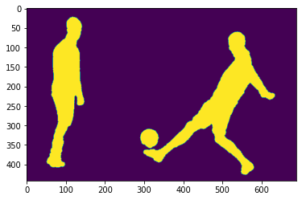

```
Segmentador felzenswalb:
```

[figure not shown]

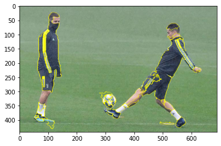

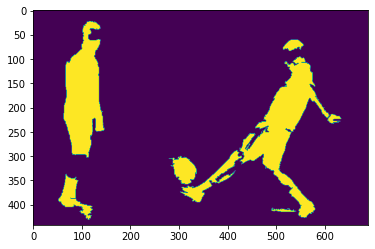

```
Matriz de confusión:
```

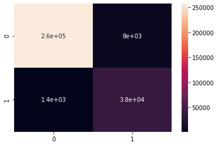

```
Resumen de resultados:
              precision    recall  f1-score   support

           0       0.99      0.97      0.98    265183
           1       0.83      0.96      0.89     39797

    accuracy                           0.97    304980
   macro avg       0.91      0.97      0.94    304980
weighted avg       0.97      0.97      0.97    304980

Intersection over Union:
0.8027306180480054
Segmentador slic:
```

[figure not shown]

[figure not shown]

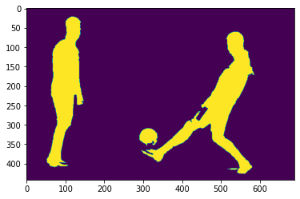

```
Matriz de confusión:
```

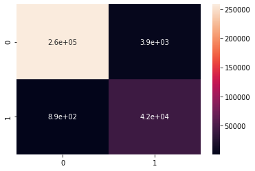

```
Resumen de resultados:
              precision    recall  f1-score   support

           0       1.00      0.98      0.99    261606
           1       0.92      0.98      0.95     43374

    accuracy                           0.98    304980
   macro avg       0.96      0.98      0.97    304980
weighted avg       0.98      0.98      0.98    304980

Intersection over Union:
0.8977957182408014
Segmentador quickshift:
```

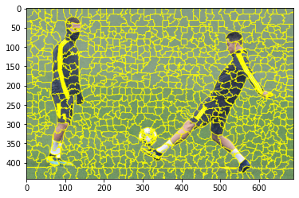

[figure not shown]

[8 more figures not shown]

```
Resumen de resultados:
              precision    recall  f1-score   support

           0       1.00      0.99      0.99    261287
           1       0.93      0.99      0.96     43693

    accuracy                           0.99    304980
   macro avg       0.96      0.99      0.97    304980
weighted avg       0.99      0.99      0.99    304980

Intersection over Union:
0.9161191554506602
```

```python
if __name__ == '__main__':
    imagen ='Futbol/futbol_1.jpg'
    ground_truth = 'Futbol/futbol_1mascara.png'
    main(imagen, ground_truth)
```

### Ejemplo ejecución 2

```
Imagen Original:
```

[figure not shown]

```
Ground Truth:
```

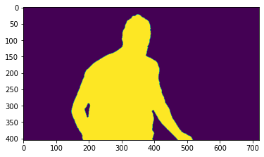

```
Segmentador felzenswalb:
```

[figure not shown]

[figure not shown]

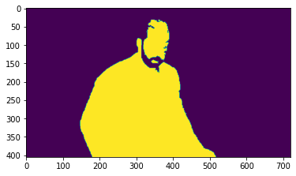

```
Matriz de confusión:
```

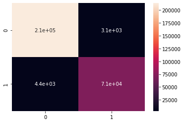

```
Resumen de resultados:
              precision    recall  f1-score   support

           0       0.98      0.99      0.98    216610
           1       0.96      0.94      0.95     74990

    accuracy                           0.97    291600
   macro avg       0.97      0.96      0.97    291600
weighted avg       0.97      0.97      0.97    291600

Intersection over Union:
0.9040487436478374
Segmentador slic:
```

[figure not shown]

[figure not shown]

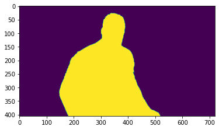

```
Matriz de confusión:
```

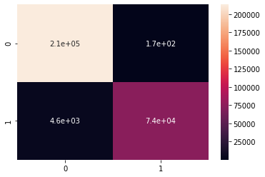

```
Resumen de resultados:
              precision    recall  f1-score   support

           0       0.98      1.00      0.99    213381
           1       1.00      0.94      0.97     78219

    accuracy                           0.98    291600
   macro avg       0.99      0.97      0.98    291600
weighted avg       0.98      0.98      0.98    291600

Intersection over Union:
0.9386807495567207
Segmentador quickshift:
```

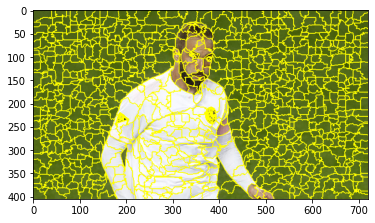

[figure not shown]

[8 more figures not shown]

```
Resumen de resultados:
              precision    recall  f1-score   support

           0       0.98      0.99      0.99    214840
           1       0.98      0.94      0.96     76760

    accuracy                           0.98    291600
   macro avg       0.98      0.97      0.97    291600
weighted avg       0.98      0.98      0.98    291600

Intersection over Union:
0.9269273113654403
```

```python
if __name__ == '__main__':
    imagen ='Futbol/futbol_3.jpg'
    ground_truth = 'Futbol/futbol_3mascara.png'
    main(imagen, ground_truth)
```

### Conclusiones

En cuanto a los problemas surgidos durante el trabajo, además de la dificultad de ajustar los parámetros de los segmentadores para un conjunto de fotos, la principal dificultad ha sido etiquetar las fotos reales para conseguir un Ground Truth fiable. Finalmente se consiguió mediante la umbralización y aplicación de filtros morfológicos a las imágenes originales.